© to me

Machine Learning - KNN January 11, 2023 9 minute read

# **K-Nearest Neighbor Classifier (KNN)**

[figure not shown]

## **1-1. 데이터 포인트 간의 거리 - 2D**

KNN 모델로 영화 평가 분류기를 구현합니다.

두 점이 서로 가깝거나 멀리 떨어져 있는 정도를 측정하기 위해 거리 공식을 사용할 것입니다.

이 예제의 경우 데이터의 차원은 다음과 같습니다.

- 영화의 러닝타임
- 영화 개봉 연도

*스타워즈*와 *인디아나 존스*를 예로 들겠습니다. *스타워즈*는 125분이며 1977년에 개봉했습니다. *인디아나 존스*는 115분이며 1981년에 개봉했습니다.

### **Practice 1**

1. `movie1`과 `movie2`라는 두 리스트을 매개 변수로 사용하는 `distance`라는 함수를 선언합니다.

   각 리스트의 첫 번째 인덱스는 영화의 러닝타임이고 두 번째 인덱스는 영화의 개봉 연도입니다. `distance` 함수는 두 리스트 사이의 거리를 반환해야 합니다.

```python
# distance 함수 구현하기
def distance(movie1, movie2):
    length_difference = (movie1[0] - movie2[0]) ** 2
    year_difference = (movie1[1] - movie2[1]) ** 2
    distance = (length_difference + year_difference) ** 0.5
    return distance
```

1. 아래 영화에 대해 `distance` 함수를 호출하여 거리를 비교해봅니다.

```python
star_wars = [125, 1977]
raiders = [115, 1981]
mean_girls = [97, 2004]
```

```python
# star_wars와 raiders의 거리
print(distance(star_wars, raiders))

# star_wars와 mean_girls의 거리
print(distance(star_wars, mean_girls))

# 스타워즈는 어느 영화와 더 비슷합니까?
# 정답:
```

```
10.770329614269007
38.897300677553446
```

## **1-2. 데이터 포인트 간의 거리 - 3D**

영화의 길이와 개봉일만을 기준으로 영화 평가 분류기를 만드는 것은 상당히 제한적입니다. 영화의 다른 속성을 데이터에 포함하여 세번째 차원을 추가해 보겠습니다.

추가된 세 번째 차원은 영화 예산입니다. 이제 영화를 나타내는 두 데이터 포인트들의 거리를 3차원으로 찾아야 합니다.

[figure not shown]

데이터의 차원이 삼차원보다 많아지면 시각화 하는 것은 어렵지만 그래도 거리를 구할 수 있습니다.

N차원의 데이터 포인트 A와 B 사이의 거리 공식은 다음과 같습니다.

$$\sqrt{(A_1 - B_1)^2 + (A_2 - B_2)^2 + ... + (A_n - B_n)^2}$$

여기서 $A_1 - B_1$은 각 데이터 포인트의 첫 번째 feature 간의 차입니다. $A_n - B_n$은(는) 각 점의 마지막 feature 간의 차입니다.

이 공식을 이용하면 N차원 공간에서 한 데이터 포인트의 K-Nearest Neighbors를 찾을 수 있습니다.

이 거리를 사용하여 label되지 않은 데이터 포인트의 가장 가까운 이웃을 찾아 결과적으로 분류를 하게 됩니다.

### **Practice 2**

1. `distance` 함수를 N개의 차원의 데이터의 거리를 반환하는 함수로 수정합니다.

```python
# distance 함수 수정
def distance(movie1, movie2):
    squared_difference = 0
    for i in range(len(movie1)):
        squared_difference += (movie1[i] - movie2[i]) ** 2
    final_distance = squared_difference ** 0.5
    return final_distance
```

1. 위 활동에서 주어진 영화들에 영화 예산 속성이 추가되었습니다. 아래 영화에 대해 `distance` 함수를 호출하여 거리를 비교해봅니다.

```python
star_wars = [125, 1977, 11000000]
raiders = [115, 1981, 18000000]
mean_girls = [97, 2004, 17000000]
```

```python
# star_wars와 raiders의 거리
print(distance(star_wars, raiders))

# star_wars와 mean_girls의 거리
print(distance(star_wars, mean_girls))

# 스타워즈는 어느 영화와 더 비슷합니까?
# 정답: mean girls
```

```
7000000.000008286
6000000.000126083
```

## **1-3. 척도가 다른 데이터: 정규화**

이 활동에서는 K-Nearest Neighborhood 알고리즘의 첫 번째 단계를 구현합니다.

1. **데이터를 정규화합니다**.
2. 가장 가까운 이웃인 `k`를 찾습니다.
3. 이러한 이웃을 기준으로 새로운 포인트를 분류합니다.

우리가 영화 예산 속성을 추가하면 데이터의 범위가 변화한것을 확인할 수 있습니다.

영화 개봉 연도와 영화 예산을 살펴보겠습니다. 어떠한 두 영화의 개봉 날짜의 최대 차이는 약 125년입니다((루미에르 브라더스는 1890년대에 영화를 만들고 있었습니다). 하지만, 어떠한 두 영화의 예산 차이는 수백만 달러가 될 수 있습니다.

거리 공식의 문제는 규모에 상관없이 모든 차원을 동등하게 취급한다는 것입니다. 이는 1년 차이가 나는 영화 개봉 년도를 1달러의 차이의 영화 예산과 같은 정도로 취급한다는 뜻입니다.

이 문제에 대한 해결책은 정규화입니다. 이는 모든 값은 0과 1 사이로 변환합니다.

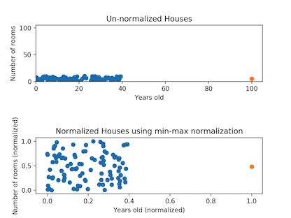

이번 실습은 최소-최대 정규화(Min-Max Normalization)를 사용할 것입니다.

$$x_{norm} = \frac{x-min(x)}{max(x)-min(x)}$$

참고: scikit-learn [`MinMaxScaler`](https://scikit-learn.org/stable/modules/generated/sklearn.preprocessing.MinMaxScaler.html#sklearn.preprocessing.MinMaxScaler)

### **1-3-1. Normalization vs Standardization**

[figure not shown]

nomalization : 데이터 전체 분포를 어떤 범위 안에 꾸겨 넣는 것

### **Practice 3**

```python
# min_max_normalize 함수 구현
def min_max_normalize(lst):
    # 1.
    minimum = min(lst)
    maximum = max(lst)
    # 2.
    normalized = []

    for value in lst:
        normalized_num = (value - minimum) / (maximum - minimum)
        normalized.append(normalized_num)

    return normalized
```

```python
release_dates = [1897, 1998, 2000, 1948, 1962, 1950, 1975, 1960,
                 2017, 1937, 1968, 1996, 1944, 1891, 1995, 1948,
                 2011, 1965, 1891, 1978]
```

```python
from pprint import pprint

# 결과값 출력하기
pprint(min_max_normalize(release_dates))
```

```
[0.047619047619047616,
 0.8492063492063492,
 0.8650793650793651,
 0.4523809523809524,
 0.5634920634920635,
 0.46825396825396826,
 0.6666666666666666,
 0.5476190476190477,
 1.0,
 0.36507936507936506,
 0.6111111111111112,
 0.8333333333333334,
 0.42063492063492064,
 0.0,
 0.8253968253968254,
 0.4523809523809524,
 0.9523809523809523,
 0.5873015873015873,
 0.0,
 0.6904761904761905]
```

## **1-4. Nearest Neighbors 찾기**

K-Nearest Neighbors 알고리즘의 두번째 단계를 구현해보겠습니다.

1. 데이터를 정규화합니다.
2. **가장 가까운 이웃 `k`를 찾습니다**.
3. 이러한 이웃을 기준으로 새로운 포인트를 분류합니다.

Label되지 않은 데이터 포인터를 분류하기 위해서는 이 데이터 포인트와 가장 가까운 `k`개의 이웃을 찾아야 합니다. 가장 적합한 `k`를 찾는 방법도 있지만, 일단은 `k=5`로 정하도록 하겠습니다.

가장 가까운 5개의 이웃을 찾기 위해서는 label되지 않은 데이터 포인트를 데이터의 다른 모든 데이터 포인트와의 거리를 계산하여 비교합니다. 이번 실습에서 구현할 함수의 반환값은 label되지 않은 한 영화에 대해 데이터의 모든 영화와의 거리가 정렬된 리스트입니다.

반환값의 예시는 다음과 같습니다.

```
[
  [0.30, 'Superman II'],
  [0.31, 'Finding Nemo'],
  ...
  ...
  [0.38, 'Blazing Saddles']
]
```

이 예에서 label되지 않은 영화와 슈퍼맨2 영화와의 거리는 0.30입니다.

```python
# 영화 데이터 받아오기
import urllib.request
import ast

movie_dataset_url = "https://raw.githubusercontent.com/inikoreaackr/ml_datasets/main/movie_dataset.txt"
movie_datasets = []
for line in urllib.request.urlopen(movie_dataset_url):
    movie_datasets.append(line.decode('utf-8'))

movie_dataset = ast.literal_eval(movie_datasets[0][16:])
movie_labels = ast.literal_eval(movie_datasets[1][15:])
```

### **Practice 4**

1. 위에 주어진 영화 데이터 중 `The Avengers` 영화를 출력해봅니다. 각 영화의 세 가지 feature은 다음과 같습니다.
   - 정규화된 영화 예산(달러)
   - 정규화된 러닝타임(분)
   - 정규화된 개봉 연도

   위 데이터의 label은 좋은 영화와 나쁜 영화를 나타냅니다. `The Avengers` 영화의 label은 1로, 좋은 영화입니다. 분류 기준은 IMDb에서 7.0 이상의 평가를 받으면 좋은 영화로 분류됩니다.

```python
print(movie_dataset['The Avengers'])
print(movie_labels['The Avengers'])
```

```
[0.018009887923225047, 0.4641638225255973, 0.9550561797752809]
1
```

1. classify 함수를 선언하고 구현해봅니다.

```python
# classify 함수를 구현
def classify(unknown, dataset, k):
    distances = []
    #Looping through all points in the dataset
    for title in dataset:
        movie = dataset[title]
        distance_to_point = distance(movie, unknown)
        #Adding the distance and point associated with that distance
        distances.append([distance_to_point, title])
    distances.sort()
    #Taking only the k closest points
    neighbors = distances[0:k]

    return neighbors
```

1. 아래 주어진 매개변수로 `classify` 함수를 테스트하고 결과를 출력합니다.
   - `[.4, .2, .9]`
   - `movie_dataset`
   - `5`

```python
# `classify` 함수를 테스트하고 결과를 출력합니다.
print(classify([.4, .2, .9], movie_dataset, 5))
```

```
[[0.08273614694606074, 'Lady Vengeance'], [0.22989623153818367, 'Steamboy'], [0.23641372358159884, 'Fateless'], [0.26735445689589943, 'Princess Mononoke'], [0.3311022951533416, 'Godzilla 2000']]
```

## **1-5. Neighbors 세기**

이 활동에서는 K-Nearest Neighbor 알고리즘 중 마지막 단계를 구현합니다.

1. 데이터를 정규화합니다.
2. 가장 가까운 이웃인 `k`를 찾습니다.
3. **이웃을 기준으로 새로운 포인트를 분류합니다**

이전 활동에서 어떠한 label되지 않은 데이터 포인트에 대해 가장 가까운 이웃 `k`개를 찾아 다음과 같은 형태로 리스트에 저장했습니다.

[output not shown]

이 리스트의 좋고 나쁜 영화의 갯수를 셈으로써 분류를 할 수 있습니다. 만약 좋은 영화로 분류된 이웃들의 갯수가 더 많아면, label되지 않은 영화는 좋은 영화로 분류됩니다. 반대의 경우에는 나쁜 영화로 분류됩니다.

### **Practice 5**

1. 이 활동에서는 위의 `classify` 함수를 수정하여 `unknown` 데이터 포인트에 대한 분류값을 반환하겠습니다. `labels` 매개 변수를 `classify`함수에 추가합니다.
1. `num_good`와 `num_bad`라는 두 변수를 만들고 각각 `0`으로 초기화합니다.
1. `labels`과 `title`을 사용하여 각 영화의 label을 받아옵니다.
   - 해당 라벨이 `0`이면 `num_bad`에 `1`을 증가시킵니다.
   - 해당 라벨이 `1`이면 `num_good`에 `1`을 증가시킵니다.
2. 이제 label되지 않은 영화를 분류할 수 있습니다.
   - `num_good`가 `num_bad`보다 크면 `1`을 반환합니다.
   - 그렇지 않으면 `0`을 반환합니다.

```python
# classify 함수 수정하기
# 1.
def classify(unknown, dataset, labels, k):
    distances = []
    for title in dataset:
        movie = dataset[title]
        distance_to_point = distance(movie, unknown)
        #Adding the distance and point associated with that distance
        distances.append([distance_to_point, title])
    distances.sort()
    #Taking only the k closest points
    neighbors = distances[0:k]
    # 2.
    num_good = 0
    num_bad = 0
    # 3.
    for neighbor in neighbors:
        title = neighbor[1]
        if labels[title] == 0:
            num_bad += 1
        elif labels[title] == 1:
            num_good += 1
    # 4.
    if num_good > num_bad:
        return 1
    else:
        return 0
```

1. 다음 파라미터를 사용하여 `classify` 함수를 호출하여 결과를 출력해봅니다.
   - 분류하려는 영화는 `[.4, .2, .9]` 입니다.
   - 훈련 데이터는 `movie_dataset` 입니다.
   - 훈련 데이터의 label은 `movie_labels`입니다.
   - `k`는 5로 지정합니다.

```python
# `classify` 함수를 테스트하고 결과를 출력합니다.
print(classify([.4, .2, .9], movie_dataset, movie_labels, 5))
```

```
1
```

## **1-6. 하나의 데이터 포인트 분류하기**

위의 활동까지는 임의의 데이터인 `[.4, .2, .9]`에만 테스트 해보았습니다. 이번 활동에서는 실제 영화 *Call Me By Your Name* 데이터를 정규화하고 예측해 볼 것입니다.

1. 먼저 분류하고자 하는 영화가 훈련 데이터에 있지는 않은지 확인해야 합니다.

```python
# "Call Me By Your Name"이 훈련 데이터에 있는지 확인하기
print("Call Me By Your Name" in movie_dataset)
```

```
False
```

1. 분류하고자 하는 영화가 훈련 데이터에 없는 것으로 확인 되면 `my_movie` 변수를 생성하고 영화 예산, 러닝타임, 개봉 연도의 순으로 데이터를 구성합니다.

```python
# my_movie 변수 생성하기
my_movie = [3500000, 132, 2017]
```

1. 주어진 `normalize_dimension` 함수를 사용하여 `my_movie`를 정규화합니다. `normalized_my_movie`라는 변수를 만들고 my_movie의 정규화된 값을 저장합니다. 결과를 출력해봅니다.

```python
# x, y, z points array 받아오기
import urllib.request
import ast
import numpy as np

points_url = "https://raw.githubusercontent.com/inikoreaackr/ml_datasets/main/points_xyz.txt"
points = []
for line in urllib.request.urlopen(points_url):
    points.append(line.decode('utf-8'))

training_x = np.array(ast.literal_eval(points[0]))
training_y = np.array(ast.literal_eval(points[1]))
training_z = np.array(ast.literal_eval(points[2]))
```

```python
def normalize_dimension(value, lst):
    minimum = min(lst)
    maximum = max(lst)
    return (value - minimum) / (maximum - minimum)

def normalize_point(pt):
    global training_x
    global training_y
    global training_z
    newx = normalize_dimension(pt[0], training_x)
    newy = normalize_dimension(pt[1], training_y)
    newz = normalize_dimension(pt[2], training_z)
    return [newx, newy, newz]
```

```python
# my_movie 변수를 정규화합니다.
normalized_my_movie = normalize_point(my_movie)
print(normalized_my_movie)
```

```
[0.00028650338197026213, 0.3242320819112628, 1.0112359550561798]
```

1. `normalized_my_movie`, `movie_dataset`, `movie_labels`, `k=5` 매개 변수를 사용하여 "classify"를 호출하고 결과를 출력합니다.

```python
# classify 함수를 호출합니다.
classify(normalized_my_movie, movie_dataset, movie_labels, 5)

# TODO: Call Me By Your Name 영화의 분류된 lable은 무엇인가요?
# 정답:
```

```
1
```

## **1-7. scikit-learn으로 KNN 구현하기**

사용 데이터: Breast Cancer Wisconsin (Diagnostic) Data Set)

사용 모델: [sklearn.neighbors.KNeighborsClassifier](https://scikit-learn.org/stable/modules/generated/sklearn.neighbors.KNeighborsClassifier.html)

```python
import pandas as pd

data_url = 'https://raw.githubusercontent.com/inikoreaackr/ml_datasets/master/breastcancer.csv'

df = pd.read_csv(data_url)
df.head()
```

|  | id | diagnosis | radius_mean | texture_mean | perimeter_mean | area_mean | smoothness_mean | compactness_mean | concavity_mean | concave points_mean | ... | texture_worst | perimeter_worst | area_worst | smoothness_worst | compactness_worst | concavity_worst | concave points_worst | symmetry_worst | fractal_dimension_worst | Unnamed: 32 |
| --- | --- | --- | --- | --- | --- | --- | --- | --- | --- | --- | --- | --- | --- | --- | --- | --- | --- | --- | --- | --- | --- |
| 0 | 842302 | M | 17.99 | 10.38 | 122.80 | 1001.0 | 0.11840 | 0.27760 | 0.3001 | 0.14710 | ... | 17.33 | 184.60 | 2019.0 | 0.1622 | 0.6656 | 0.7119 | 0.2654 | 0.4601 | 0.11890 | NaN |
| 1 | 842517 | M | 20.57 | 17.77 | 132.90 | 1326.0 | 0.08474 | 0.07864 | 0.0869 | 0.07017 | ... | 23.41 | 158.80 | 1956.0 | 0.1238 | 0.1866 | 0.2416 | 0.1860 | 0.2750 | 0.08902 | NaN |
| 2 | 84300903 | M | 19.69 | 21.25 | 130.00 | 1203.0 | 0.10960 | 0.15990 | 0.1974 | 0.12790 | ... | 25.53 | 152.50 | 1709.0 | 0.1444 | 0.4245 | 0.4504 | 0.2430 | 0.3613 | 0.08758 | NaN |
| 3 | 84348301 | M | 11.42 | 20.38 | 77.58 | 386.1 | 0.14250 | 0.28390 | 0.2414 | 0.10520 | ... | 26.50 | 98.87 | 567.7 | 0.2098 | 0.8663 | 0.6869 | 0.2575 | 0.6638 | 0.17300 | NaN |
| 4 | 84358402 | M | 20.29 | 14.34 | 135.10 | 1297.0 | 0.10030 | 0.13280 | 0.1980 | 0.10430 | ... | 16.67 | 152.20 | 1575.0 | 0.1374 | 0.2050 | 0.4000 | 0.1625 | 0.2364 | 0.07678 | NaN |

5 rows × 33 columns

```python
# id 와 Unnamed: 32 column을 삭제한 후 column들의 리스트를 출력합니다.
df.drop(columns=['id', 'Unnamed: 32'], inplace=True)
df.columns
```

```
Index(['diagnosis', 'radius_mean', 'texture_mean', 'perimeter_mean',
       'area_mean', 'smoothness_mean', 'compactness_mean', 'concavity_mean',
       'concave points_mean', 'symmetry_mean', 'fractal_dimension_mean',
       'radius_se', 'texture_se', 'perimeter_se', 'area_se', 'smoothness_se',
       'compactness_se', 'concavity_se', 'concave points_se', 'symmetry_se',
       'fractal_dimension_se', 'radius_worst', 'texture_worst',
       'perimeter_worst', 'area_worst', 'smoothness_worst',
       'compactness_worst', 'concavity_worst', 'concave points_worst',
       'symmetry_worst', 'fractal_dimension_worst'],
      dtype='object')
```

```python
# 각 column에 na 값이 있지는 않은지 확인합니다.
df.isna().any()
```

```
diagnosis                  False
radius_mean                False
texture_mean               False
perimeter_mean             False
area_mean                  False
smoothness_mean            False
compactness_mean           False
concavity_mean             False
concave points_mean        False
symmetry_mean              False
fractal_dimension_mean     False
radius_se                  False
texture_se                 False
perimeter_se               False
area_se                    False
smoothness_se              False
compactness_se             False
concavity_se               False
concave points_se          False
symmetry_se                False
fractal_dimension_se       False
radius_worst               False
texture_worst              False
perimeter_worst            False
area_worst                 False
smoothness_worst           False
compactness_worst          False
concavity_worst            False
concave points_worst       False
symmetry_worst             False
fractal_dimension_worst    False
dtype: bool
```

```python
# label이 어떻게 구성되어있나 봅니다.
df['diagnosis'].value_counts()
```

```
B    357
M    212
Name: diagnosis, dtype: int64
```

```python
# 데이터를 X와 y로 나누고 train, test 셋으로 나눕니다.
from sklearn.model_selection import train_test_split

y = df['diagnosis']
X = df.drop(columns=['diagnosis'])

X_train, X_test, y_train, y_test = train_test_split(X, y, test_size=0.3, random_state=42, shuffle=True)
```

```python
# scikit-learn의 KNN classifier을 생성하고 훈련시킵니다.
from sklearn.neighbors import KNeighborsClassifier

knn = KNeighborsClassifier()
knn.fit(X_train, y_train)
```

```
KNeighborsClassifier()
```

```python
# test 셋에 대하여 정확도를 출력해봅니다.
knn.score(X_test, y_test)
```

```
0.9590643274853801
```

## **1-8. 가장 적합한 `k` 찾기**

```python
n_neighbors_list = [1, 2, 3, 4, 5, 6, 7, 8, 9, 10]
score = []

# 가장 적합한 k를 찾아봅니다.
for k in n_neighbors_list:
  knn = KNeighborsClassifier(n_neighbors=k)
  knn.fit(X_train, y_train)
  score.append(knn.score(X_test, y_test))
```

```python
n_neighbors_list[np.argmax(score)]
```

```
9
```

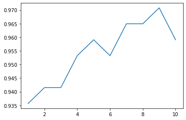

```python
import matplotlib.pyplot as plt

plt.plot(n_neighbors_list, score)
```

[figure not shown]

### TAEWON KIM

less than 1 minute read

less than 1 minute read

less than 1 minute read

less than 1 minute read